# CNV_Bench

Madyson Colton

22/04/2022

# RNAseqCNV

Implementing the RNAseqCNV caller into the SAHMRI bioinformatics pipeline following variant calling. This tool can be used to determine aneuploidy in samples missing karyotype data.

Before implementing into our pipeline, the accuracy of the caller was assessed.

## Installing on the HPC

R is required to run RNAseqCNV. An virtual environment was created to install the latest version of R and related packages.

```bash
 mamba create --name Renv r-base r-essentials
 mamba activate Renv
 mamba install -c bioconda bioconductor-biocinstaller
```

To install RNAseqCNV and dependencies, run the installCNV.R script. The RNAseqCNV package is stored on GitHub, so the devtools package is required for installation.

```bash
Rscript installCNV.R
```

```r
# Set default repo
local({r <- getOption("repos")
       r["CRAN"] <- "http://cran.r-project.org"
       options(repos=r)
})


install.packages('devtools')

library(devtools)

devtools::install_github(repo = "honzee/RNAseqCNV")
```

Some dependent packages may have to be installed manually. For me, ggpubr was causing the installation to fail. If this happens, install the dependecies via mamba/conda.

```bash
mamba install -c conda-forge r-ggpubr
```

## Locate and Tidy Data

To determine CNVs, the tool requires both sequencing counts and SNV frequencies.

The counts data should have only 2 columns - the ensembl IDs and the read counts - and no header. The SNV information can be provided as a .vcf (or vcf.gz) file following the GATK pipeline. This file should contain headers; RNAseqCNV will require the chromosome number, start position, read depth and mutant allele frequency.

The RNAseqCNV wrapper then requires the following:

- A config file
  - Directory to store the output files
  - Directory containing the counts files
  - Directory containing the vcf files
- A metadata file, containing the following 3 columns with no headers:
  - Sample ID
  - Path to the sample’s counts file
  - Path to the sample’s vcf file

### Config file

An example of the config file is given below. The variable names must not be changed. The out_dir path should be the same as the outDir for the variant calling pipeline, and should end in a “/”; the count_dir and snv_dir paths should not have a “/” at the end.

```bash
out_dir = "~/CNV/outDir/"
count_dir = "~/CNV"
snv_dir = "/cancer/storage/results"
```

### Counts data

The counts data need to be converted from an “.rData” file to a “.csv” file with two columns. As all our previous samples have been stored in a “.RDS” object in the required format, we can extract the count data from the object by running extractCountsAll.R. As we want to run the RNAseqCNV tool on all our previous samples, the summary log of our files is required.

```r
# Default repo
local({r <- getOption("repos")
r["CRAN"] <- "http://cran.r-project.org"
options(repos=r)
})

library(dplyr)

# Load sample summary file
sampleSumm <- read.csv("/data/bioinformatics/leukaemia_bank/meta_data/summary_ALL_samples.csv")

# Load count data
counts <- readRDS("/data/bioinformatics/leukaemia_bank/Rdata/countData.rds")

# For all samples
sampleNames <- sampleSumm$variant_file_ID

# Directory to save the counts files
countOut <- "~/CNV/counts/"


# Create list for failed samples
notRun <- list()

# Extract counts for all sampleNames
for(i in 1:length(sampleNames)){

  sampleID <- sampleNames[i]

  bankID <- sampleSumm[which(sampleSumm$variant_file_ID == sampleID),4]

  if(bankID %in% colnames(counts)){
    sampleCounts <- counts %>%
      dplyr::select(c("gene_id", bankID))

     names(sampleCounts) <- NULL

    write.table(sampleCounts,
                paste0(countOut, bankID, "_counts.csv"),
                col.names = FALSE,
                sep=",",
                row.names = FALSE,
                quote = FALSE,
                eol = "\r")

  print(paste0(bankID, " done."))

    }else{
    notRun[[sampleID]] <- append(bankID, "Not found")
    print(paste0(bankID, " not found"))
  }
}

# Save failed counts in a dataframe
notRun <- notRun %>%
  as.data.frame() %>%
  t()

colnames(notRun) <- c("sampleID", "status")

write.table(notRun,
            paste0(countOut, "notRun.csv"),
            row.names = FALSE,
            sep=",",
            quote = FALSE,
            eol = "\r")
```

All samples were found.

### Metadata file

#### 2020 Samples

To run the RNAseqCNV caller on all of our samples, a custom metadata sheet was generated. Our more recent samples have SNV data stored as “.vcf.gz” zipped file, whereas older samples are simply “.vcf”. The location of the sequencing counts for older samples are also stored in different locations with an esoteric file naming system, so initially only the 2020 samples were included.

```r
### Metadata table for benchmarking previous samples ###

# Default repo
local({r <- getOption("repos")
r["CRAN"] <- "http://cran.r-project.org"
options(repos=r)
})

library(stringr)
library(dplyr)

# To run on all samples, use the sample summary variant file IDs
metaD <- read.csv("/data/bioinformatics/leukaemia_bank/meta_data/summary_ALL_samples.csv")

# Only use the 2020 samples
# Paste file locations
metaD <- metaD %>%
  mutate(variant_loc = if_else(str_detect(variant_loc, "2020") == TRUE,
                                                paste0(variant_loc, "/Variants/", variant_file_ID, ".raw.vcf.gz"),
                                                paste0("")))

metaD <- metaD[metaD$variant_loc != "",]

# Add a row for counts data
metaD <- metaD %>%
  mutate(counts_loc = paste0("counts/", LB_ID, "_counts.csv"))

metaTable <- metaD %>%
  select(c("variant_file_ID", "counts_loc", "variant_loc"))


# Save table in working directory
write.table(metaTable,
            paste0("~/CNV/metadata.csv"),
            col.names = FALSE,
            sep=",",
            row.names = FALSE,
            quote = FALSE,
            eol = "\r")
```

To be able to find the /cancer/storage directories containing the vcf file, the RNAseqCNV tool will have to be initiated from the root directory. Therefore, snv_dir location in the config file is set as “/cancer/storage/results”, so this has to be removed from the metadata variant location file names.

```bash
# -i makes changes in place
# s/ substitute command
# /g global replacement, not just first instance
# \ to escape the / characters in the string

sed -i 's/\/cancer\/storage\/results\/ALL/ALL/g' metadata.csv
```

#### Older Samples

Since the older samples were stored under unusual naming systems, files ending in “.raw.vcf” were located using the Sys.glob() function in R.

```r
### Metadata table for benchmarking previous samples ###

# Default repo
local({r <- getOption("repos")
r["CRAN"] <- "http://cran.r-project.org"
options(repos=r)
})

### Load Libraries ###
library(stringr)
library(dplyr)

# Load the sample summary sheet containing the parent directories
oldMeta <- read.csv("/data/bioinformatics/leukaemia_bank/meta_data/summary_ALL_samples.csv")

# Select only the older samples and then the columns of interest
oldMeta <- oldMeta %>%
  filter(str_detect(variant_loc, "2020") == FALSE) %>%
  select(c("patientID", "variant_file_ID","LB_ID", "variant_loc"))

# Add the "/Variants" directory onto the end of the old file path
oldMeta <- oldMeta %>%
  mutate(variant_loc = paste0(variant_loc, "/Variants"))

# Change the variant_loc column name for clarity
# Create an empty new variant_loc column
colnames(oldMeta) <- c("patientID", "variant_file_ID","LB_ID", "old_loc")

oldMeta$variant_loc <- ""

# For each sample, paste the name of the file ending in ".raw.vcf"
# Set condition to handle missing/duplicate files

for(i in 1:nrow(oldMeta)){
  path <- oldMeta[i,]$old_loc
  variant_loc <- Sys.glob(file.path(path, '*.raw.vcf'))
  if(length(variant_loc) != 1){
    oldMeta[i,5] <- "NA"
  }else{
  oldMeta[i,5] <- paste(variant_loc)
}
}

# Create a metaD table also containg the counts paths (from extractCounts.R)
metaD <- oldMeta %>%
  mutate(counts_loc = paste0("counts/", LB_ID, "_counts.csv"))

# Select columns in required order for RNAseqCNV

metaTable <- metaD %>%
  select(c("variant_file_ID", "counts_loc", "variant_loc"))


# Save table in working directory
write.table(metaTable,
            paste0("~/CNV/old_metadata.csv"),
            col.names = FALSE,
            sep=",",
            row.names = FALSE,
            quote = FALSE,
            eol = "\r")
print("saved")
```

The script contains a function to generate “NA” if there are missing or duplicate .vcf files in that directory. I initially forgot to remove these from the metadata column, so ran a script to remove all rows containing NAs. The variant file location names were also edited to remove “/cancer/storage/results” as with the 2020 samples above.

```r
# Default repo
local({r <- getOption("repos")
r["CRAN"] <- "http://cran.r-project.org"
options(repos=r)
})

library(dplyr)

# Load metadata table
metaTable <- read.csv("~/CNV/old_metadata.csv")

# Remove NAs
metaTable <- metaTable[complete.cases(metaTable),]

# Save table
write.table(metaTable,
            paste0("~/CNV/old_metadata.csv"),
            col.names = FALSE,
            sep=",",
            row.names = FALSE,
            quote = FALSE,
            eol = "\r")
print("saved")
```

## Running RNAseqCNV

To run the tool, the path to the config and metadata files should be provided and specified within the RNAseqCNV_wrapper() function. The format of the variant file should also be specified (“vcf”) and the genome version (typically “hg19” in our pipeline). As this analysis is only interested in the called chromosome number, arm level figures are not required. Choosing “FALSE” for this parameter will greatly reduce run time.

```r
## Default repo
local({r <- getOption("repos")
       r["CRAN"] <- "http://cran.r-project.org"
       options(repos=r)
})

library(RNAseqCNV)

configPath <- "~/CNV/config"
metaPath <- paste0("~/CNV/metadata.csv")


RNAseqCNV_wrapper(config = configPath,
                  metadata = metaPath,
                  snv_format = "vcf",
                  genome_version = "hg19",
                  arm_lvl = FALSE)
```

The resulting estimation table was copied back to my local computer for analysis.

```bash
scp madyson.colton@edp-prd-lin-nfs01:~/CNV/outDir/estimation_table.tsv .
```

## Assessment of results

To assess the accuracy of the RNAseqCNV caller, the results were compared to our known karyotype data and subtyping.

Only good quality, diagnositic B-ALL samples were included in the benchmarking analysis. Patients who were unclassified and grouped with the “B-Other” subtype were also excluded as these are believed to have been unclassified due to missing karyotype data.

As the RNAseqCNV caller was ran twice (on the 2020 samples and then on the older samples), the results had to be combined into a single .csv file. This file was used in further analysis.

```r
# Load both results tables
cnvTable2020 <- read.table("estimation_table2020.tsv", sep = "\t", header = T)
oldCNVTable <- read.table("estimation_table.tsv", sep = "\t", header = T)

# Merge CNV data
cnvTable <- rbind(cnvTable2020, oldCNVTable)

# Save
write.csv(cnvTable, "combined_table.csv")
```

```r
### Load Libraries ###

library(dplyr)
```

```r
library(stringr)
library(ggplot2)

cbPalette <- c("#0072B2", "#E69F00", "#009E73", "#F0E442", "#56B4E9", "#D55E00", "#CC79A7")

# Load table and sample anno

cnvTable <- read.table("combined_table.csv", sep = ",", header = T)
sampleAnno <- read.csv("~/Documents/LBank/meta_data/sample_annotation.csv")
karyoData <- read.csv("~/Documents/LBank/meta_data/ALL_karyotype_data.csv")

# Merge into singular DF
allData <- left_join(cnvTable, sampleAnno, by = c("sample" = "variant_file_ID")) %>%
  left_join(karyoData, by = "LB_ID")

# Create column to extract karyotype info
allData <- allData %>%
  mutate(karyo_n = str_sub(Karyotype, start=2, end=3))

# Handle NAs in karyo_n
allData$karyo_n <- as.numeric(allData$karyo_n)
allData$karyo_n[is.na(allData$karyo_n)] <- 0

# Remove low quality samples
# Remove "others" as some of these were unclassfied due to missing cytogenetics
# Select only B-ALL and Diagnostic samples
noCyto <- allData %>% filter(exclude != "Yes",
                              !is.na(col),
                              Diagnosis.x %in% c("B-ALL", "Ph+ALL"),
                              sample.y == "Dx")
```

### Classification of patients:

- Normal = 46 chromsomes
- Hyperdiploid > 46 chromosomes
- Hypodiploid < 46 chromosomes

Number of samples with cytogenetics

| Cyto_provided | n |
| --- | --- |
| partial | 46 |
| Y | 124 |
| NA | 205 |

### Plot Accuracy

Patients were classified into groups as described, and then a new column was created to reclassify samples based on the results of RNAseqCNV. The classifications were compared.

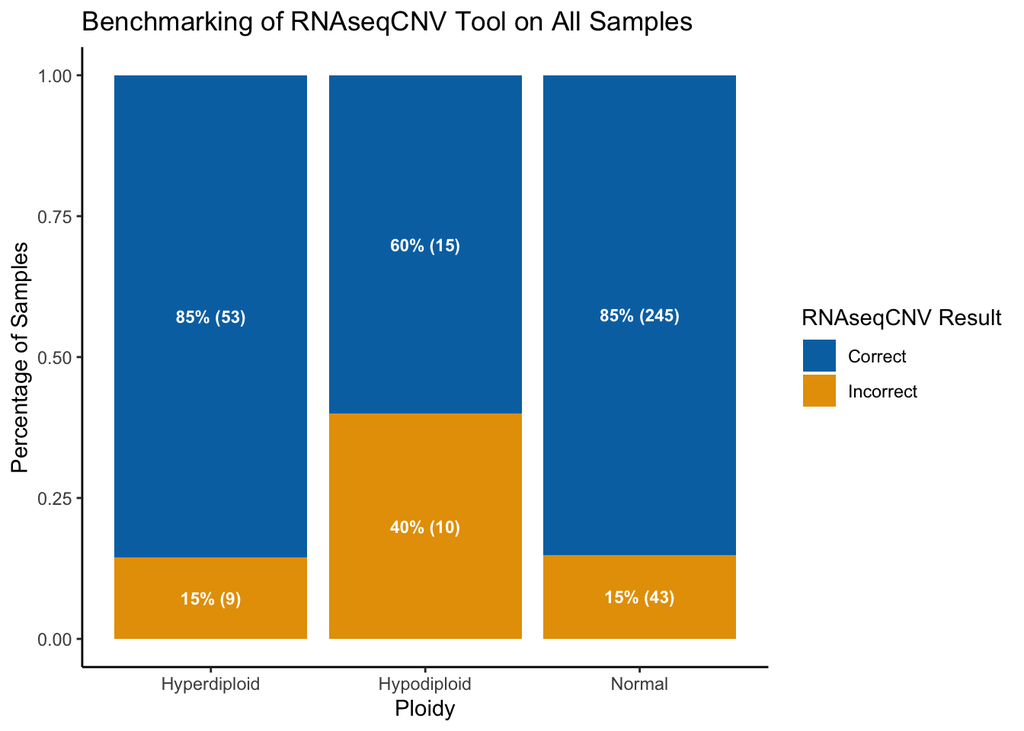

```r
# Create column to classify cnv output
# Create column for karyype classification
noCyto <- noCyto %>%
  mutate(cnvCol = if_else(chrom_n == "46", "Normal", "")) %>%
  mutate(cnvCol = if_else(chrom_n > "46", "Hyperdiploid", cnvCol)) %>%
  mutate(cnvCol = if_else(chrom_n < "46", "Hypodiploid", cnvCol)) %>%
  mutate(oldCol = if_else(col %in% c("Hyperdiploid", "Hypodiploid"), col, "Normal")) %>%
  mutate(oldCol = if_else(karyo_n == "46", "Normal", oldCol)) %>%
  mutate(oldCol = if_else(karyo_n > "46", "Hyperdiploid", oldCol)) %>%
  mutate(oldCol = if_else(karyo_n %in% c(1:45), "Hypodiploid", oldCol))

noCyto <- noCyto %>%
  mutate(correctBench = if_else(cnvCol == oldCol, "Correct", "Incorrect"))

# Create dataframe for plotting
noCytoPerc <- noCyto %>%
  count(oldCol, correctBench) %>%
  group_by(oldCol) %>%
  mutate(label_y = n/sum(n))


noCytoPlot <- noCytoPerc %>%
  ggplot(aes(x=oldCol, y=label_y, fill=correctBench)) +
  geom_col(position="stack") +
  geom_text(aes(label=paste(paste0(round(label_y*100, digits=0), "%"), paste0("(", n, ")"))),
            position=position_stack(vjust = 0.5),
            colour="white",
            size=3,
            fontface="bold") +
  scale_fill_manual(values= cbPalette) +
  theme_classic() +
  labs(x = "Ploidy",
       y = "Percentage of Samples",
       fill = "RNAseqCNV Result") +
  ggtitle("Benchmarking of RNAseqCNV Tool on All Samples")
```

Overall, RNAseqCNV matched our classification in 83% of cases.

Accuracy of the RNAseqCNV Tool

| correctBench | n | Percentage |
| --- | --- | --- |
| Correct | 313 | 83.46667 |
| Incorrect | 62 | 16.53333 |

### Comparison with Karyotype Data

The results were similar when looking only at the patients with known karyotypes, with an overall accuracy of 84%.

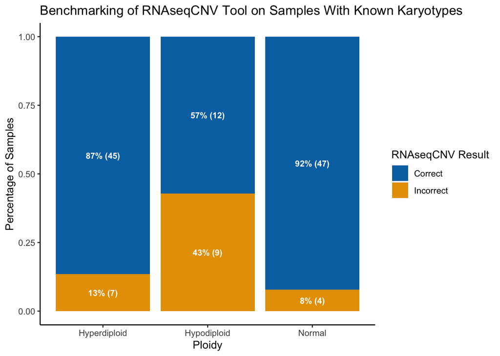

```r
cytoData <- allData %>% filter(exclude != "Yes",
                              !is.na(col),
                              Diagnosis.x %in% c("B-ALL", "Ph+ALL"),
                              sample.y == "Dx",
                              karyo_n != 0)

# Create column to classify cnv output
# Create column for karyype classification
cytoData <- cytoData %>%
  mutate(cnvCol = if_else(chrom_n == "46", "Normal", "")) %>%
  mutate(cnvCol = if_else(chrom_n > "46", "Hyperdiploid", cnvCol)) %>%
  mutate(cnvCol = if_else(chrom_n < "46", "Hypodiploid", cnvCol)) %>%
  mutate(oldCol = if_else(karyo_n == "46", "Normal", "")) %>%
  mutate(oldCol = if_else(karyo_n > "46", "Hyperdiploid", oldCol)) %>%
  mutate(oldCol = if_else(karyo_n < "46", "Hypodiploid", oldCol))

cytoData <- cytoData %>%
  select(c("patientID.x", "LB_ID", "gender", "ref", "key_alt", "primary.subtype", "Karyotype", "karyo_n", "chrom_n", "alterations", "cnvCol", "oldCol"))

# Create column comparing classification
cytoData <- cytoData %>%
  mutate(correctBench = if_else(cnvCol == oldCol, "Correct", "Incorrect"))

# Create dataframe for plotting
cytoPerc <- cytoData %>%
  count(oldCol, correctBench) %>%
  group_by(oldCol) %>%
  mutate(label_y = n/sum(n))

cytoPlot <- cytoPerc %>%
  ggplot(aes(x=oldCol, y=label_y, fill=correctBench)) +
  geom_col(position="stack") +
  geom_text(aes(label=paste(paste0(round(label_y*100, digits=0), "%"), paste0("(", n, ")"))),
            position=position_stack(vjust = 0.5),
            colour="white",
            size=3,
            fontface="bold") +
  scale_fill_manual(values= cbPalette) +
  theme_classic() +
  labs(x = "Ploidy",
       y = "Percentage of Samples",
       fill = "RNAseqCNV Result") +
  ggtitle("Benchmarking of RNAseqCNV Tool on Samples With Known Karyotypes")
```

#### Accuracy of the RNAseqCNV Tool in Matching Known Karyotype

| correctBench | n | Percentage |
| --- | --- | --- |
| Correct | 104 | 83.87097 |
| Incorrect | 20 | 16.12903 |

In many of these cases, RNAseqCNV correctly called the alterations but with low confidence, so the final chromosome number was given as 46. Of the incorrect samples, only 4 had aneuploidy as their primary clinically relevant alteration (Masked Hypodiploid = 2, Hyperdiploid = 1, Hypodiploid = 1), and one of these had an ambiguous cytogenetic report that classified the patient as having 46 chromosomes but reported Hypodiploid losses (ADII_0044: 46,XY by G-banding. Hypodiploid loss of 3,13,15,16,17,19,20 by SNParray).

#### Incorrect RNAseqCNV Classification

| patientID.x | LB_ID | gender | ref | key_alt | primary.subtype | Karyotype | karyo_n | chrom_n | alterations | cnvCol | oldCol | correctBench |
| --- | --- | --- | --- | --- | --- | --- | --- | --- | --- | --- | --- | --- |
| AYA_0726 | AYAI_0726.201362 | female | GRCh37 | ETV6:RUNX1 | ETV6-RUNX1 | “45,X,-X,del(6)(q1?3q2?1)[14]/88~99,del(6)x2,inc[cp4]/46,XX[5].nuc ish(D6Z1x2,SEC63x1,MYBx2)[131/220]/(D6Z1x4,SEC63x2,MYBx4)[62/220],(ABL1x3,BCRx4)[49/200],(ETV6,RUNX1)x3(ETV6 con RUNX1x2)[143/220]/(E… | 45 | 46 | none | Normal | Hypodiploid | Incorrect |
| AYA_0780 | AYAII_0780.201504 | male | GRCh37 | PAX5:ETV6 | PAX5alt | “45,XY,dic(9;12)(p13;p13)[3]/46,sl,+8[1]/46,XY[16].nuc ish(CRLF2x2)[200],(ABL2x2)[200],(PDGFRBx2)[200],(RUNX1T1x3,RUNX1x2)[71/200],(CDKN2Ax0,D9Z1x2)[111/200]/(CDKN2Ax1,D9Z1x2)[44/200],(ABL1x2)[200],(A… | 45 | 46 | ?9p | Normal | Hypodiploid | Incorrect |
| CHI_0802 | CHI_0802.201571 | male | GRCh37 | None | DUX4 | “45,X,-Y” | 45 | 46 | none | Normal | Hypodiploid | Incorrect |
| AYA_0814 | AYAII_0814.201699 | male | GRCh37 | P2RY8:CRLF2 | Ph-like(CRLF2) | “46,XY,del(2)(p?13p?12),del(12)(P13p11.2)[1]/47,idem+10[5]/47,idem,+6[3]/46,XY[2]” | 46 | 47 | 10+ | Hyperdiploid | Normal | Incorrect |
| ADU_0821 | ADI_0821.201574 | male | GRCh37 | BCR:ABL1 | Ph | “46,XY,t(9;22)(q34;q11.2)[1]/47,idem,del(3)(p21),+der(9)t(9;22),r(14)[10]/46,XY[29]” | 46 | 47 | 9p+, ?9q, 22+ | Hyperdiploid | Normal | Incorrect |
| AYA_0827 | AYAI_0827.201627 | male | GRCh37 | PAX5:JAK2 | Ph-like(JAK2/EPOR) | “47,XY,der(14;21)(q`0q10),+2mar[6]/46,XY[16]” | 47 | 46 | ?21+ | Normal | Hyperdiploid | Incorrect |
| CHI_0233 | CHI_0233 | male | hg19 | BCR:ABL1 | Ph | “45,XY,t(2;7)(p11.2;p1?2),dic(9;20)(p13;q11.2-13.1), t(9;22)(q34;q11.2)[10]/46,XY[10].nuc ish(CRLF2x2)[200],(ETV6,RUNX1)x2[200],(TCF3x2)[200]” | 45 | 46 | 9p-, 20q- | Normal | Hypodiploid | Incorrect |
| AYAII_0396 | AYAII_0396 | male | hg19 | BCR:ABL1 | Ph | “46-47 XY, +X, der(7;9),t(9;22),+der(22)t(9;22)[cp16]” | 46 | 47 | 7p-, 9p-, X+ | Hyperdiploid | Normal | Incorrect |
| AYAII_0128 | AYAII_0128 | female | hg19 | Hyperdiploid | Masked Hypodiploid | “61-71,XXX,-X,+1,-3,-4,-4,+6,-7,-8,-9,+10,+11,+12, -13,-14,-15,-16,-17,-17,+19,-20,+21,+22,+mar1, +mar2,+mar3[cp6]/46,XX[14].nuc ish 9q34(ABLX2),22q11(BCRX4)” | 61 | 35 | 3-, 4-, 5-, 7-, 8-, 9-, ?10q, 13-, 15-, 16-, 17-, 20- | Hypodiploid | Hyperdiploid | Incorrect |
| AYAII_0132 | AYAII_0132 | male | hg19 | None | DUX4 | “49,XY,+X,+21,+21[11]/47,XY,+12[8]/46,XY[1].ish 9q34(ABLx2),22q11(BCRx2)” | 49 | 46 | ?21, ?Xp+ | Normal | Hyperdiploid | Incorrect |
| ADII_0044 | ADII_0044 | male | hg19 | Hypodiploid | Hypodiploid | “46,XY by G-banding. Hypodiploid loss of 3,13,15,16,17,19,20 by SNParray” | 46 | 38 | 3-, 7-, 9p-, 11p-, ?12p, 12q-, 13-, 15-, 16-, 17-, 19-, 20-, ?21 | Hypodiploid | Normal | Incorrect |
| ADII_0097 | ADII_0097 | male | hg19 | Hyperdiploid | Hyperdiploid | “68,XXYY,+1,+2,+4,+4,+5,+6,+6,+8,+10,+10, +11,+11,+12,+14,+15,+19,+21,+21,+22,+22[6] 46,XY[9]” | 68 | 45 | ?1, ?2+, ?3p-, ?3q, 7-, ?8, 9p-, ?9q-, ?12p+, ?12q, ?13-, ?16-, ?17-, ?19+, ?20- | Hypodiploid | Hyperdiploid | Incorrect |
| QCTB_CHII_1105901 | CHII_QCTB.1105901 | male | hg19 | IGH@:BCL2 | BCL2/MYC | “45,XX,der(13;14)(q10;q10)?c[20].nuc ish(5’MLL,3’MLL)x2(5’MLL con3’MLLx2)[200],(ETV6x2,RUNX1x3)(ETV6 con RUNX1x1)[199/200]” | 45 | 47 | 7p-, 21+ | Hyperdiploid | Hypodiploid | Incorrect |
| CHI_0453 | CHI_0453.Dx.BM | female | GRCh37 | ETV6:NTRK3 | Ph-like(Kinase) | “47,XX,del(1)(q21),del(4)(q25q31),-9,+10,add(12)(p13),+mar[5]/46,XX[15].nuc ish(CRLF2x2)[200],(PBX1,HLF,TCF3)x2[200],(D4Z1x2,D10Z1x3,D17Z1x2)[161/200],(ABL1,BCR)x2[200],(KMT2Ax2)[200],(ETV6x2)(5’ETV6 … | 47 | 46 | ?10p+, 10q+, ?19p, ?Xp | Normal | Hyperdiploid | Incorrect |
| ALL5-RAD07 | ALL5_RAD07.PB | male | GRCh37 | BCR:ABL1 | Ph | “44,XY,der(5)(5pter->5q33::?::9q?13->9q34::11q?13->11q?21::?),-7,-9, t(9;22)(q34;q11.2),del(11)(q13q23)[19]/45,idem,+der(22)t(9;22)[16]/46,XY[4]” | 44 | 46 | 7p-, 9p- | Normal | Hypodiploid | Incorrect |
| CHI_0511 | CHI_0511.Dx.PB | female | GRCh37 | BCR:ABL1 | Ph | “45,XX,der(9)t(9;22)(p1?2;q11.2)t(9;22)(q34;q11.2),-22,der(22)t(9;22)(q34;q11.2)[10]/46,XX[10].nuc ish(CRLF2x2)[200],(PBX1,HLF,TCF3)x2[200],(D4Z1,D10Z1,D17Z1)x2[200], (ABL1x4,BCRx3)(ABL1 con BCRx3)[15… | 45 | 46 | 9p- | Normal | Hypodiploid | Incorrect |
| RNS050 | AYAII_RNS050.Dx.PB | female | GRCh37 | PAX5.p.P80R | PAX5 P80R | “45,XX(Der(7;9)q10q10 20/20” | 45 | 46 | 7p-, 9p- | Normal | Hypodiploid | Incorrect |
| ADI_0523 | ADII_0523.Dx.BM | male | GRCh37 | BCR:ABL1 | Ph | “45,XY,add(1)(q42),-7,der(9)(9qter->9q22::9p13->9q22::?),t(9;22)(q34;q11.2)[9]/44,sl,der(14)t(14;19)(p11.2:p12),-19[2]/46,XY[8].nuc ish(ABL1,BCR)x3(ABL1 con BCRx2)[174/200]” | 45 | 46 | 7p-, 9p-, ?20p | Normal | Hypodiploid | Incorrect |
| QCTB1374 | CHI_QCTB1374.0930601 | male | GRCh37 | ETV6:RUNX1 | ETV6-RUNX1 | “48,XY,+10,add(12)(p13),add(12)(p13),add(18)(q2?),+add(18),del(21)(q22) [8]/47,XY,idem,-13[6]/47,XY,+10,add(12),add(12),-13,add(18),+mar[2]/46 ,XY[6].ish add(18)(ETV6 con RUNX1+,3ÔøΩRUNX1+),del(21)(5Ô… | 48 | 46 | ?4q+, ?10p, 10q+, ?12p, ?18 | Normal | Hyperdiploid | Incorrect |
| AYAI_0599 | AYAI_0599.Dx.PB | female | GRCh37 | Hypodiploid | Masked Hypodiploid | “48,XX,+21,+21[4]/46,XX[16]” | 48 | 25 | 1-, 2-, 3-, 4-, 5-, 6-, 7-, 8-, 9-, 10-, 11-, 12-, 13-, 14-, 15-, 16-, 17-, 18-, 19-, 20-, 22- | Hypodiploid | Hyperdiploid | Incorrect |

### Comparison of Reported Chromosome Number

Next, the ability of RNAseqCNV to accurately determine the exact number of chromosomes was investigated. RNAseqCNV accurately reported 46 chromosomes in 92% of “Normal” samples; however, the exact number of chromsomes in the hyperdiploid and hypodiploid groups were only 15% and 24% accurate, respectively. Overall, the accuracy at determining exact numbers was 48%.

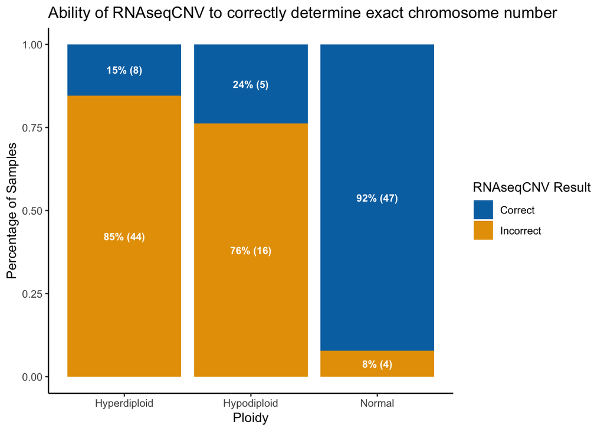

```r
# Create column comparing RNAseqCNV chrom_n with cytogenetic data karyo_n
cytoData <- cytoData %>%
  mutate(correctN = if_else(chrom_n == karyo_n, "Correct", "Incorrect"))

# Create dataframe for plotting percentages
nAltPerc <- cytoData %>%
   count(oldCol, correctN) %>%
   group_by(oldCol) %>%
   mutate(label_y = n/sum(n))

# Plot percentages
 nAltPlot <- nAltPerc %>%
   ggplot(aes(x=oldCol, y=label_y, fill=correctN)) +
   geom_col(position="stack") +
   geom_text(aes(label=paste(paste0(round(label_y*100, digits=0), "%"), paste0("(", n, ")"))),
             position=position_stack(vjust = 0.5),
             colour="white",
             size=3,
             fontface="bold") +
   scale_fill_manual(values= cbPalette) +
   theme_classic() +
   labs(x = "Ploidy",
        y = "Percentage of Samples",
        fill = "RNAseqCNV Result") +
   ggtitle("Ability of RNAseqCNV to correctly determine exact chromosome number")
```

#### Incorrectly Reported Chromosome Number

Overall, RNAseqCNV appears to underestimate the number of chromosomal alterations. This is due to the confidence metrics calculated by the tool; low confidence calls are reported but will not be included in the final chromosome number generate. Due to this, reports of alterations with a final chromosome number between 45-47 should be interpreted with caution.

In addition, RNAseqCNV calls of low hypodiploid samples should be investigated for a diagnosis of masked hypodiploid.

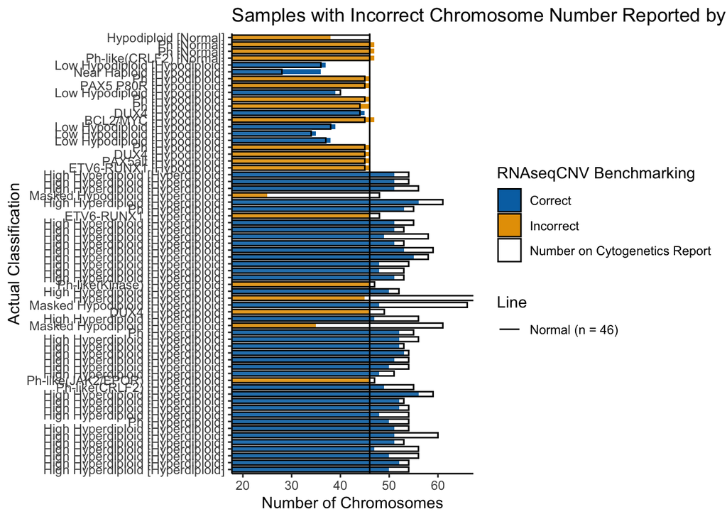

```r
# Ensure columns of interest are numeric
cytoData$karyo_n <- as.numeric(cytoData$karyo_n)
cytoData$chrom_n <- as.numeric(cytoData$chrom_n)

# Plot only incorrect N
filteredCyto <- cytoData %>% filter(correctN == "Incorrect")

# Reorder for plotting
filteredCyto <- filteredCyto[order(filteredCyto$oldCol),]

filteredCyto$patientID.x <- factor(filteredCyto$patientID.x,
                          levels = filteredCyto$patientID.x[order(filteredCyto$oldCol)])

# Labels for plotting
y_labs <- filteredCyto$oldCol
y_labs2 <- filteredCyto$primary.subtype


karyBars <- filteredCyto  %>%
  ggplot() +
  geom_col(aes(x=patientID.x, y=chrom_n, fill = correctBench), width= 0.7) +
  geom_col(aes(x=patientID.x, y= karyo_n, fill = "Number on Cytogenetics Report"), colour = "black", width = 0.7, alpha = 0.1) +
  labs(x = "Actual Classification",
       y = "Number of Chromosomes") +
  ggtitle("Samples with Incorrect Chromosome Number Reported by RNAseqCNV") +
  theme_classic() +
 # theme(axis.text.y = element_blank(), axis.line.y = element_blank()) +
  coord_flip(ylim = c(20,65)) +
  geom_hline(aes(yintercept = 46, linetype= paste("Normal (n = 46)"))) +
  scale_fill_manual(name = "RNAseqCNV Benchmarking", values = c(cbPalette[1:2], "white")) +
  scale_linetype_manual("Line", values = 1) +
  scale_x_discrete(labels = paste0(y_labs2, " [", y_labs, "]"))
```

#### Identifying Clinical Hyperdiploid or Hypodiploid ALL

Despite the inaccuracy of chromosome number calls, RNAseqCNV correctly classified 88% of our samples where aneuploidy was the key alteration.

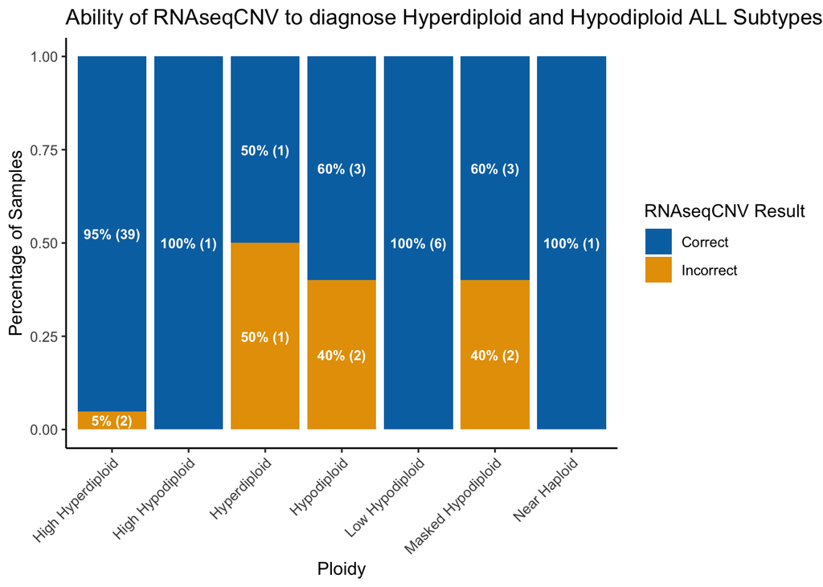

| correctBench | n | Percentage |
| --- | --- | --- |
| Correct | 54 | 88.52459 |
| Incorrect | 7 | 11.47541 |

```r
# Filter data for only clinically Hyper/Hypodiploid samples
aneuploid <- noCyto %>%
  filter(col %in% c("Hypodiploid","Hyperdiploid"))

# Create dataframe for plotting
 aneuPerc <-  aneuploid %>%
   count(primary.subtype, correctBench) %>%
   group_by(primary.subtype) %>%
   mutate(label_y = n/sum(n))

 aneuPlot <- aneuPerc %>%
   ggplot(aes(x=primary.subtype, y=label_y, fill = correctBench)) +
   geom_col(position="stack") +
   geom_text(aes(label=paste(paste0(round(label_y*100, digits=0), "%"), paste0("(", n, ")"))),
             position=position_stack(vjust = 0.5),
             colour="white",
             size=3,
             fontface="bold") +
   scale_fill_manual(values= cbPalette[1:2]) +
   theme_classic() +
   theme(axis.text.x = element_text(angle = 45, vjust=1, hjust = 1)) +
   labs(x = "Ploidy",
        y = "Percentage of Samples",
        fill = "RNAseqCNV Result") +
   ggtitle("Ability of RNAseqCNV to diagnose Hyperdiploid and Hypodiploid ALL Subtypes")
```

Of the 7 incorrect samples, two were Masked Hypodiploid, which are difficult to detect; the tool classified all masked hypodiploids as Hypodiploid, whereas in our reports the final classification differs between Hyperdiploid and Hypodiploid.

One of the incorrect samples was mentioned earlier as having ambigous cytogenetics associated with it. The patient was classified as having 46 chromosomes but the report also stated Hypodiploid losses; RNAseqCNV correctly classified this patient as Hypodiploid.

If we look at the final classification reported by our research team, the results match in 93% of cases. Of the remaining 4 incorrect cases, only one had a cytogenetics report. This sample was reported to be hyperdiploid whilst RNAseqCNV classified this as Hypodiploid; our notes suggest that this is another masked hyposiploid cases based on “clustering and TP53 mutations with VAF 0.98”. The remaining three all had alterations reported by RNAseqCNV, but these alterations were considered low confidence and so were not included in the final number reported.

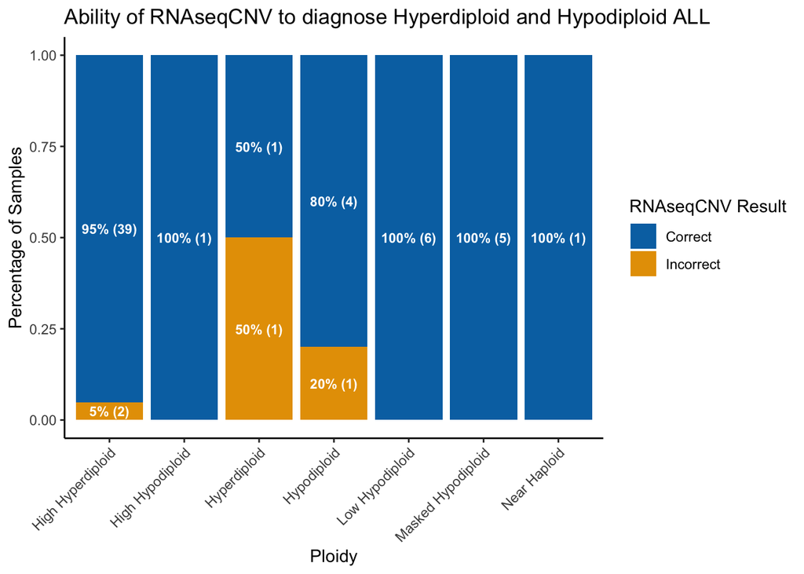

```r
# Create column comparing RNAseqCNV chrom_n with cytogenetic data karyo_n
aneuploidClin <- aneuploid %>%
  mutate(correctClin = if_else(cnvCol == col, "Correct", "Incorrect"))


aneuPercClin <-  aneuploidClin %>%
  count(primary.subtype, correctClin) %>%
  group_by(primary.subtype) %>%
  mutate(label_y = n/sum(n))

aneuPlotClin <- aneuPercClin %>%
  ggplot(aes(x=primary.subtype, y=label_y, fill = correctClin)) +
  geom_col(position="stack") +
  geom_text(aes(label=paste(paste0(round(label_y*100, digits=0), "%"), paste0("(", n, ")"))),
            position=position_stack(vjust = 0.5),
            colour="white",
            size=3,
            fontface="bold") +
  scale_fill_manual(values= cbPalette[1:2]) +
  theme_classic() +
  theme(axis.text.x = element_text(angle = 45, vjust=1, hjust = 1)) +
  labs(x = "Ploidy",
       y = "Percentage of Samples",
       fill = "RNAseqCNV Result") +
  ggtitle("Ability of RNAseqCNV to diagnose Hyperdiploid and Hypodiploid ALL")
```

## Conclusion

RNAseqCNV is able to correctly identify CNVs in patients where aneuploidy is their primary alteration. This tool can be used for research purposes to reclassify “B-Other” patients with missing cytogenetics, and can be adapted to be used in our pipeline on new samples.